# Structural Equation Modeling: What Fun if We Cannot Run in Mplus

Biostatistics

Psychology/Sociology

SEM

Mplus

lavaan (R)

Model Fit Statistics

The introduction composed on Lecture Notes from authors: Michael Zyphur, Lesa Hoffman and Johnny Lin;  
Review of SEM;  
Read correlation/covariance matrix as input in Mplus & lavaan (R);  
Run SEM in Mplus & lavaan (R);  
Model fit indices

Hai Nguyen  
June 20, 2022

- Specification (estimating in our models) $\Rightarrow$ Measurement model specification (relationships among observed and latent variables, including variances and covariance) $\Rightarrow$ Structural model specification (classic regression relationships among (latent) variables of substantive interest)
- SEM = measurement model + structural model
  - Specify # of factors and factor loadings with **“BY” or =~**
  - Specify regression/covariance with **“ON” or ~** and **“WITH” or ~~**
- SEM solves two regression problems:
  - Simple structural models (path analysis)
  - Variables measured with error (CFA)

## First build

*Quick reference of `lavaan` syntax* (Web Page (2021))

*Quick reference of `lavaan` syntax*

Introduce some of the most frequently used syntax in **lavaan**

- **~ predict**, used for regression of observed outcome to observed predictors (e.g., y ~ x)
- **=~ indicator**, used for latent variable to observed indicator in factor analysis measurement models (e.g., f =~ q + r + s)
- **~~ covariance** (e.g., x ~~ x)
- **~1** intercept or mean (e.g., x ~ 1 estimates the mean of variable x)
- **1*** fixes parameter or loading to one (e.g., f =~ 1*q)
- **NA*** frees parameter or loading (useful to override default marker method, (e.g., f =~ NA*q)
- **a*** labels the parameter ‘a’, used for model constraints (e.g., f =~ a*q)

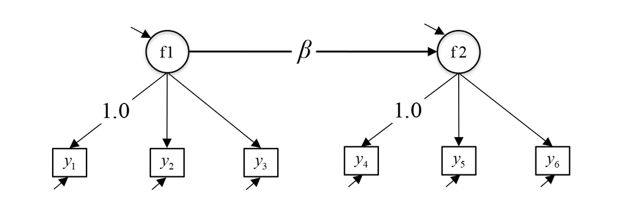

Extract from lecture note Web Page (2019)

### Demonstation 1

- **Model in Mplus:**  
  f1 BY y1-y3;  
  f2 BY y4-y6;  
  f2 ON f1;
- **Model in lavaan (R):**  
  f1 =~ y1+y2+y3  
  f2 =~ y4+y5+y6  
  f2 ~ f1

### Demonstation 2

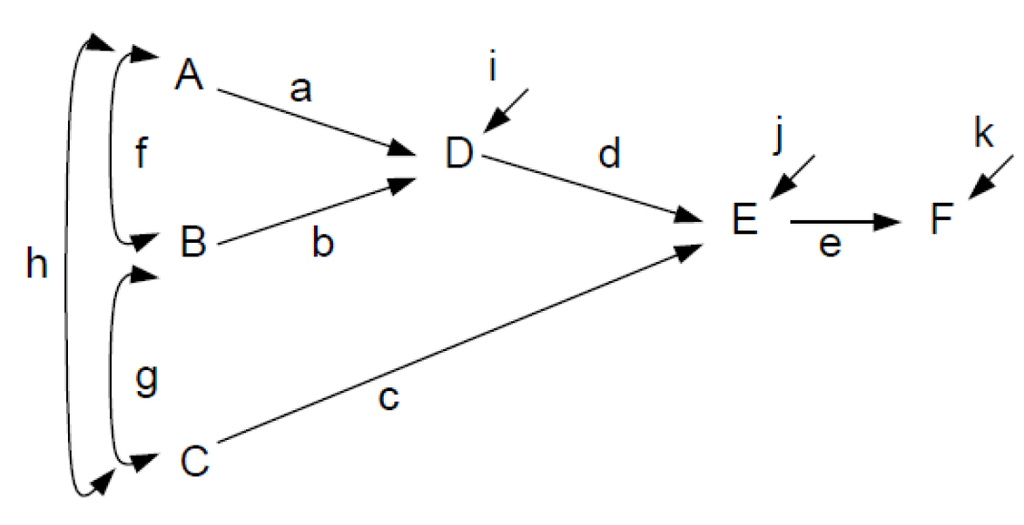

Extract from lecture note Web Page (2022)

- **Model in Mplus:**

! Required code to estimate regression paths  
D ON A B;  
E ON D C;  
F ON E;  
! Outcome intercepts and residual variances estimated by default  
[D E F]; D E  
! To bring A, B, and C predictors into the likelihood,  
! Request their covariances  
A B C WITH A B C;  
! Predictor means and variances then estimated by default  
[A B C]; A B C;

- **Model in lavaan (R):**

D ~ A+B  
E ~ D+C  
F ~ E

D ~ 1; D ~~ D

A B C ~~ A B C

A ~ 1; A~~A

## Be aware of 2 types of path models

- Unstandardized $\rightarrow$ predicts scale sensitive original variables:
  - Useful for comparing across groups (whenever absolute values matter)
  - Parameters predict the variables’ means, variance s, and covariances
- Standardized $\rightarrow$ predicts 𝑧 scored versions of variables
  - Useful when comparing effects within a solution (are then on same scale)
  - Model parameters predict the variables’ correlations

Refer more in Web Page (2022)

## Confusing terminolgy

- *Predictors* are known as **exogenous** variables
- *Outcomes* are known as **endogenous** variables
- Variables that are *both* at once are called **endogenous** variables

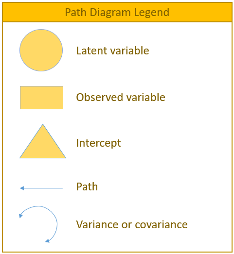

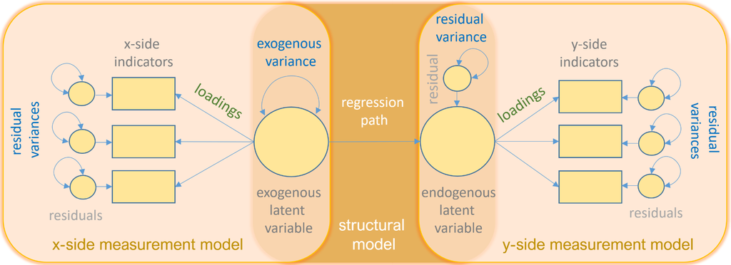

*How set up in Mplus to run FIML:*

Trick in Mplus

- By default **in Mplus** , *truly* exogenous predictor variables cannot have missing data, the same as in any general(ized) linear model
  - Cases with missing predictors are **listwise deleted** (incomplete data then are assumed missing completely at random ), no matter which
  - Because *truly* exogenous predictors are not part of likelihood function + Log likelihood (LL) contains $\hat{y}_i$ for each person and $\sigma^2_e$ for each outcome
    - So LL can’t be calculated without the predictors that create each $\hat{y}_i$
- But truly exogenous predictors also do not have assumed distributions
  - Good when you have non normally distributed predictors (e.g., ANOVA)!
- We thought full information ML allows missing data???
  - NO: only endogenous outcomes can be incomplete (then assumed missing at random, which means random only after conditioning on model variables
  - BTW, we can add other variables into the likelihood but not the model to help (untestable) missing at random assumption using AUXILIARY option
    - Is a “saturated correlates” approach (they just covary with all outcomes)
- Mplus allows a work around: you *can* bring exogenous predictors into the likelihood by listing their means, variances, or covariances as parameters $\rightarrow$ **predictors then become “outcomes”**
  - Even if nothing predicts the predictor (i.e., it’s not really an outcome)
  - Incomplete “endogenous predictors” can be included assuming missing at random (MAR), but they also then have distributional assumptions (MNV)
    - Historically Mplus has not let endogenous predictors have other distributions, so you may have to make non normal predictors an outcome of something else
    - But there may be ways to trick it in doing this that I haven’t found yet

## Steps in Model Building

### Practical Steps: 2 Step

2-step (Anderson and Gerbing (1988))

- CFA with “fully-saturated” covariance structure
  - Allow all latent variables to freely covary (i.e., only WITH, no ON)
  - Removes structural model from estimation of fit
  - Misfit can only be due to measurement model problems
- Obtain fit to evaluate measurement model
- Estimate structural model with regression
- Obtain fit & contrast with previous model
  - Changes in fit due to structural model misfit

### Practical Steps: 4 Step

4-step (Mulaik and Millsap (2000), Hayduk and Glaser (2000), and Bollen (2000))

- Exploratory search for # of factors
- CFA with fully-saturated covariance structure
- Estimate structural model with regression
- Test nested/alternative models

## An example

Mathieu and Farr (1991) article about *“Further evidence for the discriminant validity of measures of organizational commitment, job involvement, and job satisfaction”*

- Measured organizational commitment, performance, job involvement, and job satisfaction and other variables
- Show discriminant validity with good-fitting CFA that specifies each as a distinct latent variable
- Then show non-huge inter-correlations among factors
- Data (Means – Stdeviations – Correlation) from engineers is used, in Appendix A

```r
print("Mathieu & Farr 1991.txt")
```

```
[1] "Mathieu & Farr 1991.txt"
```

[output not shown]

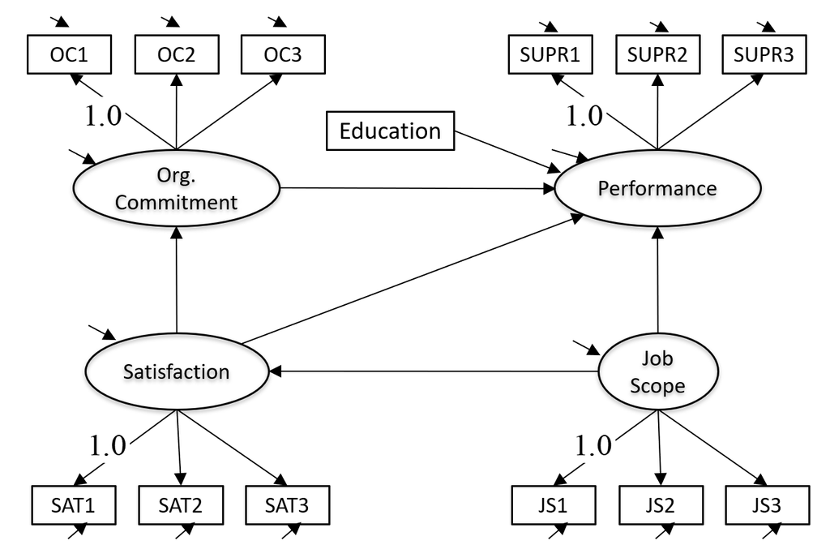

Extract from lecture note (Web Page (2019))

```r
writeLines(readLines("Mathieu & Farr 1991.txt"))
```

### Set up Mplus in Rmarkdown

```r
knitr::opts_chunk$set(engine.path = list(
  mplus = "C:/Program Files/Mplus/Mplus"
))
```

```r
knitr::knit_engines$set(mplus = function(options) {
    code <- paste(options$code, collapse = "\n")
    fileConn<-file("formplus.inp")
    writeLines(code, fileConn)
    close(fileConn)
    out  <- system2("C:/Program Files/Mplus/Mplus", "formplus.inp")
    fileConnOutput <- file("formplus.out")
    mplusOutput <- readLines(fileConnOutput)
    knitr::engine_output(options, code, mplusOutput)
})
```

### Run Mplus in Rmarkdown

```
Title: CFA Example

Data: File is Mathieu & Farr 1991.txt;

Type is Means Stdeviations Correlation;

Nobservations = 483;

Variable:
Names are
OC1 OC2 OC3 ! Organizational commitment
JI1 JI2 JI3 ! Job involvement
SAT1 SAT2 SAT3 ! Job satisfaction
JS1 JS2 JS3 ! Job scope
SELF1 SELF2 SELF3 ! Self ratings of performance
SUPR1 SUPR2 SUPR3 ! Supervisor ratings of performance
Education
PostTen ! Position tenure
OrgTen ! Organizational tenure
Age;

UseVariables are OC1-OC3 SAT1-SAT3
JS1-JS3 SUPR1-SUPR3 Education;

Analysis:

Model:
OC by OC1 OC2 OC3;
SAT by SAT1 SAT2 SAT3;
JS by JS1 JS2 JS3;
PERF by SUPR1 SUPR2 SUPR3;

PERF on OC SAT JS Education;
OC on SAT;
SAT on JS;

Output: Tech1 Tech8 standardized sampstat;
```

```
Mplus VERSION 8.6
MUTHEN & MUTHEN
02/25/2023  12:47 AM

INPUT INSTRUCTIONS

  Title: CFA Example

  Data: File is Mathieu & Farr 1991.txt;

  Type is Means Stdeviations Correlation;

  Nobservations = 483;

  Variable:
  Names are
  OC1 OC2 OC3 ! Organizational commitment
  JI1 JI2 JI3 ! Job involvement
  SAT1 SAT2 SAT3 ! Job satisfaction
  JS1 JS2 JS3 ! Job scope
  SELF1 SELF2 SELF3 ! Self ratings of performance
  SUPR1 SUPR2 SUPR3 ! Supervisor ratings of performance
  Education
  PostTen ! Position tenure
  OrgTen ! Organizational tenure
  Age;

  UseVariables are OC1-OC3 SAT1-SAT3
  JS1-JS3 SUPR1-SUPR3 Education;

  Analysis:

  Model:
  OC by OC1 OC2 OC3;
  SAT by SAT1 SAT2 SAT3;
  JS by JS1 JS2 JS3;
  PERF by SUPR1 SUPR2 SUPR3;

  PERF on OC SAT JS Education;
  OC on SAT;
```

[output cut: 678 more lines]

```
        Ending Time:  00:47:25
       Elapsed Time:  00:00:00



MUTHEN & MUTHEN
3463 Stoner Ave.
Los Angeles, CA  90066

Tel: (310) 391-9971
Fax: (310) 391-8971
Web: www.StatModel.com
Support: Support@StatModel.com

Copyright (c) 1998-2021 Muthen & Muthen
```

### Run lavaan (R)

We have no full dataset, but do have a sample mean, standard deviation and correlation matrix. Due to [`lavaan` supports covariance matrix as input but not correlation matrix](https://stackoverflow.com/questions/61148096/correlation-matrix-as-input-for-lavaan), we need to convert correlation matrix to covariance matrix to fit your model.

#### Convert correlation to covariance matrix

First, I run [SAS (proc iml)](https://blogs.sas.com/content/iml/2010/12/10/converting-between-correlation-and-covariance-matrices.html) for easier manipulate the correlation matrix transfer to covariance matrix. However, we could use `rcompanion::fullPTable()` function in R to do the job.

```r
# in SAS
PROC IML;
/** convert correlation matrix to covariance matrix **/
lR={1       .       .       .       .       .       .       .       .       .       .       .       .       .       .       .       .       .       .       .       .       .,
    .76 1       .       .       .       .       .       .       .       .       .       .       .       .       .       .       .       .       .       .       .       .,
    .67 .68 1       .       .       .       .       .       .       .       .       .       .       .       .       .       .       .       .       .       .       .,
    .26 .2      .22 1       .       .       .       .       .       .       .       .       .       .       .       .       .       .       .       .       .       .,
    .28 .25 .17 .43 1       .       .       .       .       .       .       .       .       .       .       .       .       .       .       .       .       .,
    .34 .33 .26 .52 .52 1       .       .       .       .       .       .       .       .       .       .       .       .       .       .       .       .,
    .57 .57 .55 .09 .2      .21 1       .       .       .       .       .       .       .       .       .       .       .       .       .       .       .,
    .55 .53 .55 .16 .2      .21 .84 1       .       .       .       .       .       .       .       .       .       .       .       .       .       .,
    .48 .46 .49 .15 .23 .21 .79 .71 1       .       .       .       .       .       .       .       .       .       .       .       .       .,
    .36 .31 .31 .14 .13 .16 .46 .42 .48 1       .       .       .       .       .       .       .       .       .       .       .       .,
    .42 .36 .38 .15 .12 .14 .51 .5      .5      .7      1       .       .       .       .       .       .       .       .       .       .       .,
    .32 .34 .37 .11 .13 .13 .47 .46 .46 .65 .64 1       .       .       .       .       .       .       .       .       .       .,
    .21 .19 .13 .14 .18 .15 .31 .29 .31 .32 .5      .1      1       .       .       .       .       .       .       .       .       .,
    .21 .17 .1      .14 .16 .15 .25 .23 .29 .37 .25 .17 .81 1       .       .       .       .       .       .       .       .,
    .22 .18 .12 .15 .14 .12 .33 .29 .31 .39 .29 .15 .82 .82 1       .       .       .       .       .       .       .,
    .15 .13 .02 .23 .13 .18 .09 .07 .04 .19 .16 .08 .23 .15 .14 1       .       .       .       .       .       .,
    .16 .09 -.01    .17 .07 .05 .09 .09 .07 .25 .24 .16 .22 .28 .19 .59 1       .       .       .       .       .,
    .14 .09 -.01    .13 .04 .06 .07 .05 .07 .2      .17 .09 .22 .19 .23 .59 .62 1       .       .       .       .,
    .06 .09 .01 .07 .11 .16 .09 .1      .04 .14 .04 .05 .2      .19 .15 .15 .17 .15 1       .       .       .,
    .03 .06 .1      .17 .19 .17 .02 .01 .1      .15 .04 .09 .03 .05 .06 .1      .16 .07 .1      1       .       .,
    .1      .09 .1      .1      .16 .15 -.001   .02 .04 .12 .05 -.01    .03 .03 .05 .001    .18 .02 .05 .52 1       .,
    .14 .1      .12 .07 .15 .17 -.01    .01 -.001   .12 .03 .06 .1      .01 .12 .06 .18 .04 .07 .46 .8      1 };

p=ncol(lR);  * Number of columns in the lower triangular correlation matrix;
R=J(p,p,0);    * Initialize the correlation matrix;
uR=(lR`); * Transpose the lower triangular matrix to upper;
R=lR<>uR; * Select the max of the lower and upper matrices;
print R;       * Complete correlation matrix;

/** standard deviations of each variable **/
c = {.89    1   1.11    1.1 1.31    1.11    .86 .88 .89 .43 .4  .41 .85 .92 .77 1.11    1.11    1.09    1.05    6.18    8.62    9.92};
D = diag(c);

S = D*R*D; /** covariance matrix **/
print S;
quit;
```

#### Load lavaan

Second, load `lavaan`

```r
library(lavaan)
```

#### Read covariance as input

Third, we read in the lower half of the covariance matrix (including the diagonal)

```r
options(width = 300)
lower <- '
0.7921
0.6764    1
0.661893  0.7548  1.2321
0.25454   0.22    0.26862   1.21
0.326452  0.3275  0.247197  0.61963 1.7161
0.335886  0.3663  0.320346  0.63492 0.756132  1.2321
0.436278  0.4902  0.52503   0.08514 0.22532   0.200466 0.7396
0.43076   0.4664  0.53724   0.15488 0.23056   0.205128 0.635712 0.7744
0.380208  0.4094  0.484071  0.14685 0.268157  0.207459 0.604666 0.556072 0.7921
0.137772  0.1333  0.147963  0.06622 0.073229  0.076368 0.170108 0.158928 0.183696 0.1849
0.14952   0.144   0.16872   0.066   0.06288   0.06216  0.17544  0.176    0.178    0.1204    0.16
0.116768  0.1394  0.168387  0.04961 0.069823  0.059163 0.165722 0.165968 0.167854 0.114595  0.10496 0.1681
0.158865  0.1615  0.122655  0.1309  0.20043   0.141525 0.22661  0.21692  0.234515 0.11696   0.17    0.03485   0.7225
0.171948  0.1564  0.10212   0.14168 0.192832  0.15318  0.1978   0.186208 0.237452 0.146372  0.092   0.064124  0.63342  0.8464
0.150766  0.1386  0.102564  0.12705 0.141218  0.102564 0.218526 0.196504 0.212443 0.129129  0.08932 0.047355  0.53669  0.580888 0.5929
0.148185  0.1443  0.024642  0.28083 0.189033  0.221778 0.085914 0.068376 0.039516 0.090687  0.07104 0.036408  0.217005 0.15318  0.119658 1.2321
0.158064  0.0999 -0.012321  0.20757 0.101787  0.061605 0.085914 0.087912 0.069153 0.119325  0.10656 0.072816  0.20757  0.285936 0.162393 0.726939 1.2321
0.135814  0.0981 -0.012099  0.15587 0.057116  0.072594 0.065618 0.04796  0.067907 0.09374   0.07412 0.040221  0.20383  0.190532 0.193039 0.713841 0.750138 1.1881
0.05607   0.0945  0.011655  0.08085 0.151305  0.18648  0.08127  0.0924   0.03738  0.06321   0.0168  0.021525  0.1785   0.18354  0.121275 0.174825 0.198135 0.171675 1.1025
0.165006  0.3708  0.68598   1.15566 1.538202  1.166166 0.106296 0.054384 0.55002  0.39861   0.09888 0.228042  0.15759  0.28428  0.285516 0.68598  1.097568 0.471534 0.6489 38.1924
0.76718   0.7758  0.95682   0.9482  1.806752  1.43523 -0.007413 0.151712 0.306872 0.444792  0.1724 -0.035342  0.21981  0.237912 0.33187  0.0095682 1.722276 0.187916 0.45255 27.701232 74.3044
1.236032  0.992   1.321344  0.76384 1.94928   1.871904 -0.085312 0.087296 -0.008829 0.511872 0.11904 0.244032 0.8432   0.091264 0.916608 0.660672 1.982016 0.432512 0.72912 28.200576 68.40832 98.4064  '

mathieu.cov <-
    getCov(lower, names = c(
      "OC1", "OC2", "OC3", # Organizational commitment
      "JI1", "JI2", "JI3", # Job involvement
      "SAT1", "SAT2", "SAT3", # Job satisfaction
      "JS1", "JS2", "JS3", # Job scope
      "SELF1", "SELF2", "SELF3", # Self ratings of performance
      "SUPR1", "SUPR2", "SUPR3", # Supervisor ratings of performance
      "Education",
      "PostTen", # Position tenure
      "OrgTen", # Organizational tenure
      "Age"
    ))
```

#### Model fit

Fourth, we fit model

```r
options(width = 300)
mathieu.model <- '
  # latent variables
    OC  =~ OC1  + OC2   + OC3
    SAT =~ SAT1 + SAT2  + SAT3
    JS  =~ JS1  + JS2   + JS3
    PERF=~ SUPR1+ SUPR2 + SUPR3
  # regressions
    PERF ~ OC + SAT + JS + Education
    OC   ~ SAT
    SAT  ~ JS
'
fit <- sem(mathieu.model,
           sample.cov = mathieu.cov,
           sample.nobs = 483)
summary(fit, standardized = TRUE)
```

```
lavaan 0.6-10 ended normally after 47 iterations

  Estimator                                         ML
  Optimization method                           NLMINB
  Number of model parameters                        30

  Number of observations                           483

Model Test User Model:

  Test statistic                               126.544
  Degrees of freedom                                60
  P-value (Chi-square)                           0.000

Parameter Estimates:

  Standard errors                             Standard
  Information                                 Expected
  Information saturated (h1) model          Structured

Latent Variables:
                   Estimate  Std.Err  z-value  P(>|z|)   Std.lv  Std.all
  OC =~
    OC1               1.000                               0.771    0.868
    OC2               1.124    0.049   22.934    0.000    0.867    0.868
    OC3               1.128    0.056   20.156    0.000    0.870    0.784
  SAT =~
    SAT1              1.000                               0.816    0.950
    SAT2              0.949    0.031   30.970    0.000    0.775    0.881
    SAT3              0.900    0.034   26.719    0.000    0.735    0.827
  JS =~
    JS1               1.000                               0.356    0.828
    JS2               0.950    0.048   19.671    0.000    0.338    0.845
    JS3               0.886    0.049   17.969    0.000    0.315    0.770
  PERF =~
    SUPR1             1.000                               0.822    0.743
    SUPR2             1.071    0.073   14.751    0.000    0.881    0.797
    SUPR3             1.028    0.070   14.666    0.000    0.845    0.779

Regressions:
```

[output cut: 14 more lines]

```
   .OC2               0.246    0.026    9.479    0.000    0.246    0.246
   .OC3               0.473    0.038   12.491    0.000    0.473    0.385
   .SAT1              0.072    0.012    6.089    0.000    0.072    0.098
   .SAT2              0.173    0.015   11.389    0.000    0.173    0.224
   .SAT3              0.250    0.019   13.186    0.000    0.250    0.317
   .JS1               0.058    0.006   10.172    0.000    0.058    0.314
   .JS2               0.046    0.005    9.427    0.000    0.046    0.285
   .JS3               0.068    0.006   12.061    0.000    0.068    0.408
   .SUPR1             0.547    0.050   11.028    0.000    0.547    0.447
   .SUPR2             0.446    0.049    9.106    0.000    0.446    0.365
   .SUPR3             0.464    0.047    9.814    0.000    0.464    0.394
   .OC                0.298    0.029   10.122    0.000    0.501    0.501
   .SAT               0.392    0.033   11.982    0.000    0.589    0.589
    JS                0.127    0.012   10.489    0.000    1.000    1.000
   .PERF              0.595    0.071    8.417    0.000    0.881    0.881
```

#### Fit statistics

Fifth, fit indices

```r
options(width = 300)
#fit statistics
summary(fit, fit.measures=TRUE)
```

```
lavaan 0.6-10 ended normally after 47 iterations

  Estimator                                         ML
  Optimization method                           NLMINB
  Number of model parameters                        30

  Number of observations                           483

Model Test User Model:

  Test statistic                               126.544
  Degrees of freedom                                60
  P-value (Chi-square)                           0.000

Model Test Baseline Model:

  Test statistic                              3614.872
  Degrees of freedom                                78
  P-value                                        0.000

User Model versus Baseline Model:

  Comparative Fit Index (CFI)                    0.981
  Tucker-Lewis Index (TLI)                       0.976

Loglikelihood and Information Criteria:

  Loglikelihood user model (H0)              -5138.829
  Loglikelihood unrestricted model (H1)      -5075.557

  Akaike (AIC)                               10337.657
  Bayesian (BIC)                             10463.058
  Sample-size adjusted Bayesian (BIC)        10367.840

Root Mean Square Error of Approximation:

  RMSEA                                          0.048
  90 Percent confidence interval - lower         0.036
  90 Percent confidence interval - upper         0.060
  P-value RMSEA <= 0.05                          0.599
```

[output cut: 45 more lines]

```
   .OC2               0.246    0.026    9.479    0.000
   .OC3               0.473    0.038   12.491    0.000
   .SAT1              0.072    0.012    6.089    0.000
   .SAT2              0.173    0.015   11.389    0.000
   .SAT3              0.250    0.019   13.186    0.000
   .JS1               0.058    0.006   10.172    0.000
   .JS2               0.046    0.005    9.427    0.000
   .JS3               0.068    0.006   12.061    0.000
   .SUPR1             0.547    0.050   11.028    0.000
   .SUPR2             0.446    0.049    9.106    0.000
   .SUPR3             0.464    0.047    9.814    0.000
   .OC                0.298    0.029   10.122    0.000
   .SAT               0.392    0.033   11.982    0.000
    JS                0.127    0.012   10.489    0.000
   .PERF              0.595    0.071    8.417    0.000
```

## Model Fit Statistics

We focus on the 5 commonly used:

1- **Model chi-square** is the chi-square statistic we obtain from the maximum likelihood statistic (in `lavaan`, this is known as the Test Statistic for the Model Test User Model)  
2- **CFI** is the Comparative Fit Index – values can range between 0 and 1 (values greater than 0.90, conservatively 0.95 indicate good fit)  
3- **TLI** Tucker Lewis Index which also ranges between 0 and 1 (if it’s greater than 1 it should be rounded to 1) with values greater than 0.90 indicating good fit. If the CFI and TLI are less than one, the CFI is always greater than the TLI.  
4- **RMSEA** is the root mean square error of approximation In lavaan, you also obtain a p-value of close fit, that the RMSEA < 0.05. If you reject the model, it means your model is not a close fitting model.  
5- **SRMR** is standardized root mean squared residual to test close fit. Also we also obtain a p-value of close fit, that the RMSEA < 0.05. If you reject the model, it means your model is not a close fitting model.

In general, researchers should avoid sample sizes less than 100 when testing small degrees of freedom models. In fact, science and math education researchers should avoid reporting the RMSEA when sample sizes are smaller than 200, particularly when combined with small degrees of freedom. Small degrees of freedom do not tend to result in rejection of correctly specified models for the TLI, CFI, and SRMR, particularly if they tested using larger sample sizes (Taasoobshirazi and Wang (2016)).

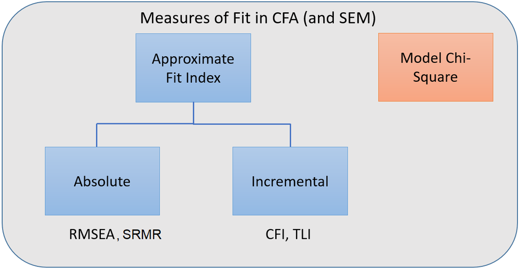

**(be continued)**

## Summary

Anderson, James C., and David W. Gerbing. 1988. “Structural Equation Modeling in Practice: A Review and Recommended Two-Step Approach.” Journal Article. *Psychological Bulletin* 103 (3): 411–23. https://doi.org/10.1037/0033-2909.103.3.411.

Bollen, Kenneth A. 2000. “Modeling Strategies: In Search of the Holy Grail.” Journal Article. *Structural Equation Modeling: A Multidisciplinary Journal* 7 (1): 74–81. https://doi.org/10.1207/S15328007SEM0701_03.

Hayduk, Leslie A., and Dale N. Glaser. 2000. “Doing the Four-Step, Right–2–3, Wrong–2–3: A Brief Reply to Mulaik and Millsap; Bollen; Bentler; and Herting and Costner.” Journal Article. *Structural Equation Modeling* 7: 111–23. https://doi.org/10.1207/S15328007SEM0701_06.

Mathieu, John E., and James L. Farr. 1991. “Further Evidence for the Discriminant Validity of Measures of Organizational Commitment, Job Involvement, and Job Satisfaction.” Journal Article. *Journal of Applied Psychology* 76 (1): 127–33. https://doi.org/10.1037/0021-9010.76.1.127.

Mulaik, Stanley A., and Roger E. Millsap. 2000. “Doing the Four-Step Right.” Journal Article. *Structural Equation Modeling: A Multidisciplinary Journal* 7 (1): 36–73. https://doi.org/10.1207/S15328007SEM0701_02.

Taasoobshirazi, Gita, and Shanshan Wang. 2016. “The Performance of the SRMR, RMSEA, CFI, and TLI: An Examination of Sample Size, Path Size, and Degrees of Freedom.” Journal Article. *Journal of Applied Quantitative Methods* 11 (3): 31.

Web Page. 2019. https://melbourne.figshare.com/articles/media/Mplus_Workshop_at_The_University_of_Melbourne_February_4-8_2019_5_Days_/7797620.

———. 2021. https://stats.oarc.ucla.edu/r/seminars/rsem/.

———. 2022. https://www.lesahoffman.com/PSQF6249/index.html.